# Early-warnings signals in ecological systems Sesión 3

### 1.4.3 Consejos prácticos

Para **optimizar el rendimiento**:

- Usa **ventanas más grandes**si no necesitas tanta resolución.
- Reduce la **cantidad de especies** en tests exploratorios.
- Usa solo una réplica o subset de datos antes de escalar.
- Correlo primero con `winsize = 50` y sin `theta`para ver el tiempo base.
- Puedes cronometrar el tiempo con `system.time()`en R:

1. Sensibilidad a **E** y **tau**

Los dos métodos S-map son **muy sensibles** a los valores de **E** (dimensión de embedding) y **tau** (retardo).

- Si **E** es demasiado bajo, no capturas la dinámica; si es demasiado alto, sobreajustas y metes ruido.
- Elegir**tau**inadecuado puede “desenfocar” la reconstrucción del atractor.

**Tip rápido:** usa `simplex()` y `s_map()` (paquete **rEDM**) para tantear qué combinaciones minimizan el error de predicción antes de lanzarte al cálculo de estabilidad.

### 1.4.4 2. Efectos de estacionalidad o ciclos compartidos

En series **estacionales o cíclicas**, los picos compartidos por todas las especies (por ejemplo primavera-invierno) pueden **inflar artificialmente** los valores de causalidad y de interacción estimados.

- Parecerá que todas las especies están “fuertemente acopladas”, cuando en realidad solo responden al mismo ciclo ambiental.

**Solución recomendada (Ushio et al. 2018):**

- **Eliminar tendencia**:`detrend_ts()`
- **Eliminar estacionalidad**:`deseason_ts()`
- Ambas funciones vienen en `EWSmethods`. Úsalas antes de `uniJI()` o`multiJI()`.

3. Escalado / normalización

Para evitar que una especie con abundancia enorme “domine” el ajuste,**escala todas las series** a varianza o rango comparables entre si.

- `uniJI()` y `multiJI()` traen el argumento `scale = TRUE`, que te lo resuelve en un paso.

4. Períodos largos sin cambios

Si alguna especie queda **plana** (sin variación) durante un lapso igual o mayor al tamaño de la ventana (`winsize`):

- `uniJI()` devuelve **NA** para esa ventana.
- `multiJI()` **descarta** la serie problemáticas.

**Por qué sucede:** el algoritmo necesita calcular derivadas locales; si todo es constante, la matriz Jacobiana se vuelve singular o indefinida.

3)**Jacobianos por Autocorrelación**

### 1.4.5 ¿Qué propone este enfoque?

A diferencia de `uniJI()` y `multiJI()`, que se basan en reconstrucciones no lineales tipo *empirical dynamic modelling*(EDM), este método alternativo propuesto por **Williamson y Lenton (2015)** utiliza un enfoque más clásico y **lineal**:  
**Modelos autorregresivos multivariados de primer orden** (AR(1)).

Este método:

- $λ_j$ = autovalor del Jacobiano → nos da **estabilidad local**
- $a_j$= autovalor de la matriz de autocorrelación
- $\Delta t$= intervalo temporal entre observaciones

### 1.4.6 ¿Y qué pasa con $\Delta t$?

En datos simulados lo puedes conocer, pero en datos reales **rara vez sabes el tiempo exacto entre eventos dinámicos reales**.  
Por eso, **`EWSmethods` asume** Δt=1 como valor por defecto, aunque puedes cambiarlo manualmente si sabes más sobre la frecuencia o el tiempo de muestreo.

## 1.5 🔍 Interpretación del índice `multiAR`

Similar al enfoque `multiJI()`, este método estima una **medida local de estabilidad de Lyapunov**, **pero con una escala diferente**:

| Valor de `multiAR` | Interpretación |
| --- | --- |
| `multiAR < 0` | Estable (las perturbaciones se amortiguan) |
| `multiAR > 0` | Inestable (las perturbaciones se amplifican) |
| `multiAR ≈ 0` | Transición crítica (pérdida de estabilidad) |
| `multiAR` creciente | Señal de estrés creciente en el sistema |

**El umbral aquí es 0** (no 1, como en los Jacobianos EDM). La interpretación es la misma, pero hay que prestar atención a esta diferencia cuando compares enfoques.

```r
eg_multiAR <- multiAR(data = simTransComms$community1[,2:7], winsize = 25)
```

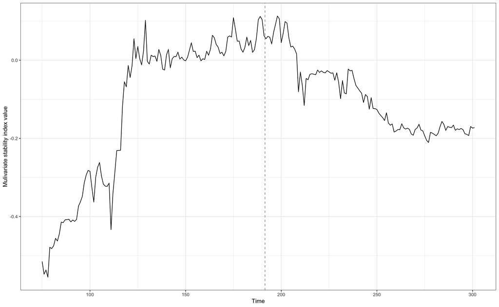

```r
multiAR_plot_data <- merge(simTransComms$community1,eg_multiAR,by="time") # combine the mvi data with the raw time series

ggplot(multiAR_plot_data,aes(x = time, y = multiAR)) + geom_line() + geom_vline(xintercept = multiAR_plot_data$inflection_pt,col = "grey60", linetype = "dashed") + theme_bw() + xlab("Time") + ylab("Mulivariate stability index value")
```

La función `multiAR()` presenta **limitaciones similares a las de los índices basados en S-map** (`multiJI` y `uniJI`):

- Es **sensible a la longitud de las series de tiempo**: si las series son muy cortas, la estimación del índice puede ser poco confiable o incluso fallar.
- También es sensible a **qué especies incluyes**: algunas pueden tener más peso en la estimación del índice dependiendo de su dinámica (por ejemplo, si están muy correlacionadas o tienen abundancias altas).

**Dato práctico observado por los autores:**  
Aunque no está formalmente especificado, **se ha observado empíricamente** que los modelos autorregresivos multivariados requieren **al menos 16 puntos de tiempo** para funcionar correctamente.

[output not shown]

### 1.5.1 **Recomendaciones según situación**

#### 1.5.1.1 **Usa `mvi()`si…**

- Tienes **pocos datos** o series muy ruidosas.
- Quieres un **análisis exploratorio rápido**.
- Solo necesitas un **termómetro general** del sistema, sin inferir interacciones específicas.
- Estás trabajando con sistemas con **mucha estocasticidad** o datos de baja resolución.

#### 1.5.1.3 **Usa `multiAR()` si…**

- Necesitas **velocidad de cálculo** (muchas réplicas, análisis por lotes, etc.).
- Tienes un sistema **más cercano al comportamiento lineal** (o no necesitas precisión no lineal).
- Las series son moderadamente largas (**≥ 16 puntos**) y con buena variabilidad.
- Ya conoces o puedes asumir el **paso temporal Δt** (o aceptas el valor por defecto).

### 1.5.2 Consejo extra para análisis comparativo

Puedes usar los **tres índices sobre la misma comunidad** y:

1. **Comparar visualmente** su evolución a lo largo del tiempo.
2. Buscar **coincidencias en tendencias crecientes** como evidencia más robusta de pérdida de resiliencia.
3. Analizar **dónde divergen** y discutir a qué puede deberse (modelo, sensibilidad, ruido, tipo de dinámica).

## 1.6 4) **Información de Fisher (FI)**

La **Información de Fisher (FI)** es un concepto clásico de estadística (Fisher y Russell, 1922) que cuantifica **cuánta información contienen los datos sobre un parámetro no observado**.

Este enfoque ha sido adaptado para evaluar la **dinámica y estabilidad de sistemas complejos** (Ahmad et al., 2016), bajo la idea de que **sistemas estables tienden a ser más informativos** y menos impredecibles.

En `EWSmethods`, se implementa una **versión simplificada para series de tiempo discretas** siguiendo la propuesta de Karunanithi et al. (2008), con la siguiente fórmula:

$$FI \approx
4\sum_{i=1}^m[q_i−q_{i+1}]^2$$

Con:

- q_i es la **probabilidad estimada** de que el sistema esté en el “estado” i,
- m es el **número de estados posibles** que puede asumir el sistema.

### 1.6.1 ¿Qué significa “estado” en este contexto?

Un “estado” se define **comparando ventanas consecutivas de tiempo** en los datos multivariados.

- Si la **diferencia absoluta entre dos ventanas** (en todas las especies) **es menor a una referencia de incertidumbre**, entonces se consideran **el mismo estado**.
- Si no, se consideran **estados distintos**.

## 1.7 Interpretación del índice FI

Cuando el índice FI **disminuye**, se interpreta como que **la estabilidad del sistema también está disminuyendo**.

¿Por qué? Porque:

- En sistemas estables, los estados tienden a repetirse → alta información → FI alto.
- En sistemas inestables, hay más fluctuación → menos regularidad → FI bajo.

```r
eg.sost <- t(apply(simTransComms$community1[,3:7], MARGIN = 2, FUN = sd)) # define size-of-states using the standard deviation of each species separately. Must be wide format hence t()

egFI <- FI(data = simTransComms$community1[,2:7], sost =  eg.sost, winsize = 25,winspace = 1, TL = 90)$FI
```

Si graficamos nuevamente el índice de **Información de Fisher (FI)**, podemos observar que **hay diferencias claras en la estabilidad antes y después del punto de inflexión**, es decir, el momento en que la comunidad atraviesa una transición crítica.

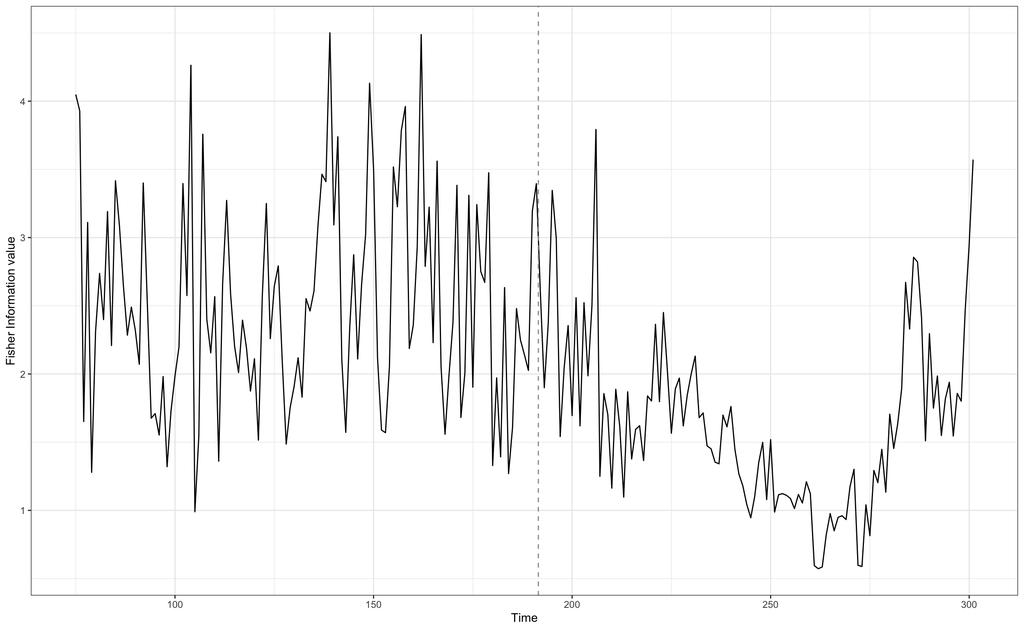

```r
fi_plot_data <- merge(simTransComms$community1,egFI,by="time") # combine the mvi data with the raw time series

ggplot(fi_plot_data,aes(x = time, y = FI)) + geom_line() + geom_vline(xintercept = fi_plot_data$inflection_pt,col = "grey60", linetype = "dashed") + theme_bw() + xlab("Time") + ylab("Fisher Information value")
```